# Lab 05: Wine Quality

Author

Trishla Nair

Published

October 5, 2024

## Methods

```python
# imports
import pandas as pd
from sklearn.model_selection import train_test_split, GridSearchCV
from sklearn.pipeline import Pipeline
from sklearn.compose import ColumnTransformer
from sklearn.impute import SimpleImputer
from sklearn.preprocessing import StandardScaler, OneHotEncoder
from sklearn.neighbors import KNeighborsClassifier
import seaborn as sns
from sklearn.metrics import accuracy_score
import matplotlib.pyplot as plt
from joblib import dump
```

### Data

```python
# load data
wine_train = pd.read_csv(
    "https://cs307.org/lab-05/data/wine-train.csv",
)
wine_test = pd.read_csv(
    "https://cs307.org/lab-05/data/wine-test.csv",
)
```

The data set contains 4157 observations and 12 main features.

```python
# summary statistics
# summary statistics
wine_train.shape
```

```
(4157, 13)
```

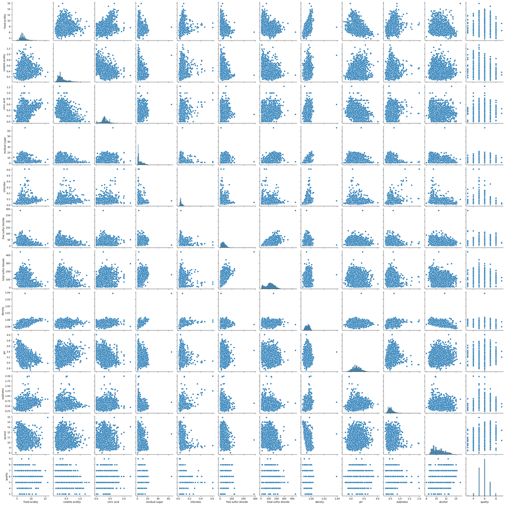

```python
# visualizations
sns.pairplot(wine_train)
```

Using the pairplot, we can see the correlation of each feature to find the ones that are highly correlated. Higher correlation indicates that the 2 variables are dependent.

### Models

```python
# process data for ML
X_train = wine_train.drop("quality", axis=1)
y_train = wine_train["quality"]

# create X and y for test
X_test = wine_test.drop("quality", axis=1)
y_test = wine_test["quality"]
```

```python
X_train.dtypes
```

```
fixed acidity           float64
volatile acidity        float64
citric acid             float64
residual sugar          float64
chlorides               float64
free sulfur dioxide     float64
total sulfur dioxide    float64
density                 float64
pH                      float64
sulphates               float64
alcohol                 float64
color                    object
dtype: object
```

```python
# find numeric and categorical features
numeric_features = X_train.select_dtypes(include=["int64", "float64"]).columns
categorical_features = X_train.select_dtypes(include=["object"]).columns
```

```python
# define how to handle missing values and scale features for numeric features
numeric_transformer = Pipeline(
    steps=[
        ("Mean Imputer", SimpleImputer(strategy="mean")),
        ("Standardization", StandardScaler()),
    ]
)

# define how to handle missing values and encode features for categorical features
categorical_transformer = Pipeline(
    steps=[
        ("Modal Imputer", SimpleImputer(strategy="most_frequent")),
        ("One-Hot Encoder", OneHotEncoder(handle_unknown="ignore")),
    ]
)

# create general preprocessor
preprocessor = ColumnTransformer(
    transformers=[
        ("Numeric Transformer", numeric_transformer, numeric_features),
        ("Categorical Transformer", categorical_transformer, categorical_features),
    ],
    remainder="drop",
)

# Create the pipeline
pipeline = Pipeline(steps=[("Preprocessor", preprocessor), ("Classifier", KNeighborsClassifier())])
# define the parameter grid for grid search
param_grid = {
    "Classifier__n_neighbors": range(1,100),
    "Classifier__metric": ["euclidean", "manhattan"],
}

# perform grid search with cross-validation
grid_search = GridSearchCV(pipeline, param_grid, cv=5, scoring="neg_mean_absolute_error")
grid_search.fit( X_train, y_train)
```

```
GridSearchCV(cv=5,
             estimator=Pipeline(steps=[('Preprocessor',
                                        ColumnTransformer(transformers=[('Numeric '
                                                                         'Transformer',
                                                                         Pipeline(steps=[('Mean '
                                                                                          'Imputer',
                                                                                          SimpleImputer()),
                                                                                         ('Standardization',
                                                                                          StandardScaler())]),
                                                                         Index(['fixed acidity', 'volatile acidity', 'citric acid', 'residual sugar',
       'chlorides', 'free sulfur dioxide', 'total sulfur dioxide', 'density',
       'pH', 'sulphat...
                                                                         'Transformer',
                                                                         Pipeline(steps=[('Modal '
                                                                                          'Imputer',
                                                                                          SimpleImputer(strategy='most_frequent')),
                                                                                         ('One-Hot '
                                                                                          'Encoder',
                                                                                          OneHotEncoder(handle_unknown='ignore'))]),
                                                                         Index(['color'], dtype='object'))])),
                                       ('Classifier', KNeighborsClassifier())]),
             param_grid={'Classifier__metric': ['euclidean', 'manhattan'],
                         'Classifier__n_neighbors': range(1, 100)},
             scoring='neg_mean_absolute_error')
```

To preprocess the data, we used One Hot encoding and Simple imputation by means of the most frequent for categorical variables and the mean for numerical variables. Then to help aid with the model, I used Grid search.

## Results

```python
# report model metrics
print(grid_search.best_params_)
print(grid_search.best_score_)

# Save the model for submission to the autograder
dump(grid_search, 'wine-quality.joblib')
```

```
{'Classifier__metric': 'manhattan', 'Classifier__n_neighbors': 46}
-0.4931407942238268
```

```
['wine-quality.joblib']
```

## Discussion

Using UC Irvine’s wine data, it shows some benefits,however, there are some issues with data. though it is large, it does not consider scent. An important part of diagnosing a wine is to classify it based on scent and notes.

### Conclusion

Based on the MAE value, the model is a good fit for the data.